# Walking speed

# 1 Description of DataSchema variable

The description of harmonised variable is the following:

- Short name: `walking_speed_c`
- Variable label: `Walking speed - Continuous`
- Variable description: `Walking speed - Continuous. It is measured assessing the time that is taken to walk a distance.`
- Value type: `continuous`
- Category missings:

| **Code** | **Category Label** |
| --- | --- |
| 991 | CAPI/interviewer error |
| 992 | Impute |
| 993 | Disable to measure |
| 994 | Not attempt/not done |
| 995 | Does not answer |
| 996 | Not applicable |
| 997 | Refuse |
| 998 | Do not know |
| 999 | Missing |

- Short name: `walking_speed`
- Variable label: `Walking speed`
- Variable description: `Walking speed. It is measured assessing the time that is taken to walk a distance.Discrete variable: value 0 = <=25%; value 1 = >25%.`
- Value type: `Categorical`
- Category coding:

| **Code** | **Category Label** |
| --- | --- |
| 0 | <=25% |
| 1 | >25% |

- Category missings:

| **Code** | **Category Label** |
| --- | --- |
| 991 | CAPI/interviewer error |
| 992 | Impute |
| 993 | Disable to measure |
| 994 | Not attempt/not done |
| 995 | Does not answer |
| 996 | Not applicable |
| 997 | Refuse |
| 998 | Do not know |
| 999 | Missing |

# 2 Data process

## 2.1 England

### 2.1.1 Wave 1

#### 2.1.1.1 Study-specific variable description

| **Name** | `mmwlka` | `mmwlkb` |
| --- | --- | --- |
| **Label** | `Time taken for first walk (seconds) in a distance of 8 feet (244cm) at their usual walking pace` | `Time taken for second walk (seconds) in a distance of 8 feet (244cm) at their usual walking pace` |
| **Table name** | `wave_1_core_data_v3` | `wave_1_core_data_v3` |
| **Missings** | `-9 = Refusal; -8 = Don't Know; -1 = Not applicable` | `-9 = Refusal; -8 = Don't Know; -1 = Not applicable` |
| **Description** |  |  |

mmwlka

| Sample size | Missing values |
| --- | --- |
| 12099 | 5893 |

Values

|  | No-missings | -9 | -8 | -1 | NA |
| --- | --- | --- | --- | --- | --- |
| Frequency | 6206.00 | 4.00 | 0 | 5889.00 | 0 |
| Percentage | 51.29 | 0.03 | 0 | 48.67 | 0 |

Summary

| Min. | 1st Qu. | Median | Mean | 3rd Qu. | Max. |
| --- | --- | --- | --- | --- | --- |
| 0.03 | 2.42 | 3.005 | 6.015 | 3.988 | 819 |

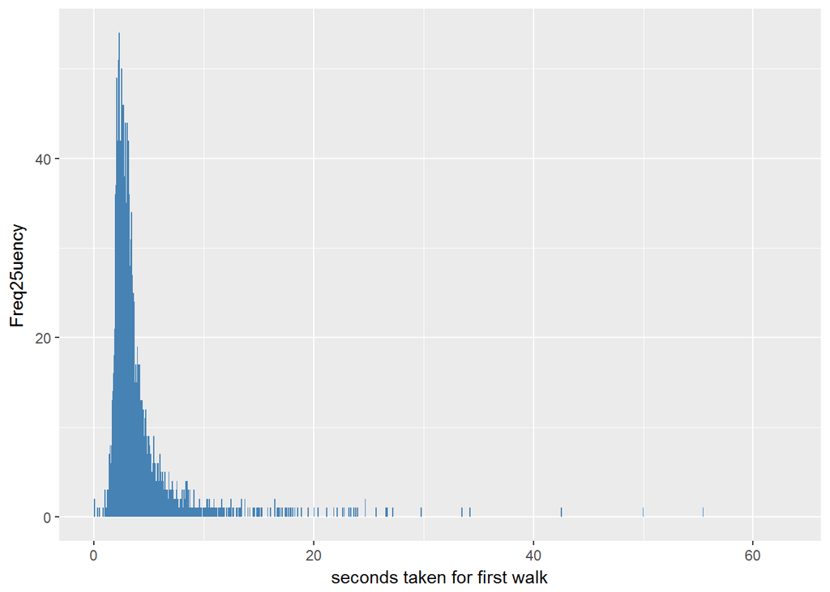

```
## It has to be noted that there are 45 individuals reporting more than 63 seconds:
```

```
##  [1] 373.00 194.00 400.00 324.00 281.00 353.00 345.00 390.00 252.00 340.00
## [11] 101.90 510.00 283.00 463.00 246.00 426.00 333.00 308.00 670.00 318.00
## [21] 247.00 307.00 306.00 253.00 595.00 263.00 201.00 282.00 219.00 253.00
## [31] 506.00 175.00 153.00 291.00 284.00 408.00 490.00 320.00 819.00 156.00
## [41] 605.00 321.00  90.67 315.00 400.00
```

mmwlkb

| Sample size | Missing values |
| --- | --- |
| 12099 | 5919 |

Values

|  | No-missings | -9 | -8 | -1 | NA |
| --- | --- | --- | --- | --- | --- |
| Frequency | 6180.00 | 0 | 1.00 | 5918.00 | 0 |
| Percentage | 51.08 | 0 | 0.01 | 48.91 | 0 |

Summary

| Min. | 1st Qu. | Median | Mean | 3rd Qu. | Max. |
| --- | --- | --- | --- | --- | --- |
| 0.03 | 2.33 | 2.87 | 5.955 | 3.75 | 860 |

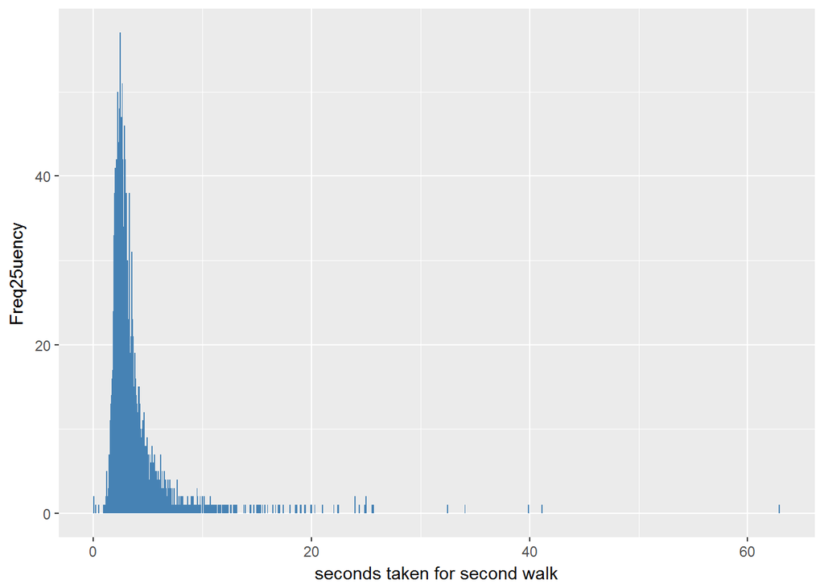

```
## It has to be noted that there are 49 individuals reporting more than 63 seconds:
```

```
##  [1] 295 198 375 213 341 330 314 173 333 171 309 317 473 237 396 354 370
## [18] 312 860 306 232 395 309 255 290 211 240 267 229 281 281 562 190 159
## [35] 284 317 444 443 229 619 203 321 599 426 231 289 250 309 227
```

#### 2.1.1.2 Harmonisation algorithm

To compute the harmonize variable `walking_speed_c` from the study-specific variables it has to be computed the mean and recoded as follows:

- `-9 Refusal into 997`
- `-8 Don't Know into 998`
- `-1 Not applicable into 996`
- `NA into 999`

To compute the harmonized variable `walking_speed` from `walking_speed_c` it has to be recoded as follows:

- `walking_speed_c <=25% into 0`
- `walking_speed_c >25% into 1`

**R script:**

```r
# walking_speed_c
ELSA_ds_w1 <- tibble(id = ELSA_w1_walking$id)
n <- length(ELSA_w1_walking$id)
mmwlk <- rep(0, length(ELSA_w1_walking$mmwlka))
for (i in 1:n) {
    if (ELSA_w1_walking$mmwlka[i] < 0 & ELSA_w1_walking$mmwlkb[i] >= 0)
        mmwlk[i] <- 2.44/ELSA_w1_walking$mmwlkb[i]

    if (ELSA_w1_walking$mmwlkb[i] < 0 & ELSA_w1_walking$mmwlka[i] >= 0)
        mmwlk[i] <- 2.44/ELSA_w1_walking$mmwlka[i]

    if (ELSA_w1_walking$mmwlka[i] < 0 & ELSA_w1_walking$mmwlkb[i] < 0) {
        mmwlk[i] <- min(ELSA_w1_walking$mmwlka[i], ELSA_w1_walking$mmwlkb[i])
    }

    if (ELSA_w1_walking$mmwlka[i] >= 0 & ELSA_w1_walking$mmwlkb[i] >= 0)
        mmwlk[i] <- 2.44/mean(c(ELSA_w1_walking$mmwlka[i], ELSA_w1_walking$mmwlkb[i]))
}
rm(i)

ELSA_ds_w1 <- tibble(id = ELSA_w1_walking$id)
ELSA_ds_w1$walking_speed_c <- car::recode(as.numeric(unlist(mmwlk)), "-9=997; -8=998; -1=996")
ELSA_ds_w1$walking_speed_c <- labelled(ELSA_ds_w1$walking_speed_c, labels = c(Missing = 999,
    `Do not know` = 998, Refuse = 997, `Not applicable` = 996, `Does not answer` = 995,
    `Not attempt not done` = 994, `Disable to measure` = 993, Impute = 992,
    `CAPI interviewer error` = 991))

# walking_speed
q25 <- quantile(car::recode(ELSA_ds_w1$walking_speed_c, "999=NA; 997=NA; 998=NA; 996=NA"),
    probs = 1/4, na.rm = TRUE, names = FALSE)

ELSA_ds_w1$walking_speed <- car::recode(ELSA_ds_w1[[2]], "0:q25=0; (q25+0.0000000000001):900=1")
ELSA_ds_w1$walking_speed <- labelled(ELSA_ds_w1[[3]], labels = c(`<=25%` = 0,
    `>25%` = 1, Missing = 999, `Do not know` = 998, Refuse = 997, `Not applicable` = 996,
    `Does not answer` = 995, `Not attempt not done` = 994, `Disable to measure` = 993,
    Impute = 992, `CAPI interviewer error` = 991))
```

#### 2.1.1.3 Statistical description of the new harmonised variable

Walking speed

| Sample size | Missing values |
| --- | --- |
| 12099 | 5893 |

Values

|  | No-missings | 991 | 992 | 993 | 994 | 995 | 996 | 997 | 998 | 999 | NA |
| --- | --- | --- | --- | --- | --- | --- | --- | --- | --- | --- | --- |
| Frequency | 6206.00 | 0 | 0 | 0 | 0 | 0 | 5889.00 | 4.00 | 0 | 0 | 0 |
| Percentage | 51.29 | 0 | 0 | 0 | 0 | 0 | 48.67 | 0.03 | 0 | 0 | 0 |

Summary

| Min. | 1st Qu. | Median | Mean | 3rd Qu. | Max. |
| --- | --- | --- | --- | --- | --- |
| 0.00319 | 0.6305 | 0.8313 | 0.8873 | 1.021 | 69.71 |

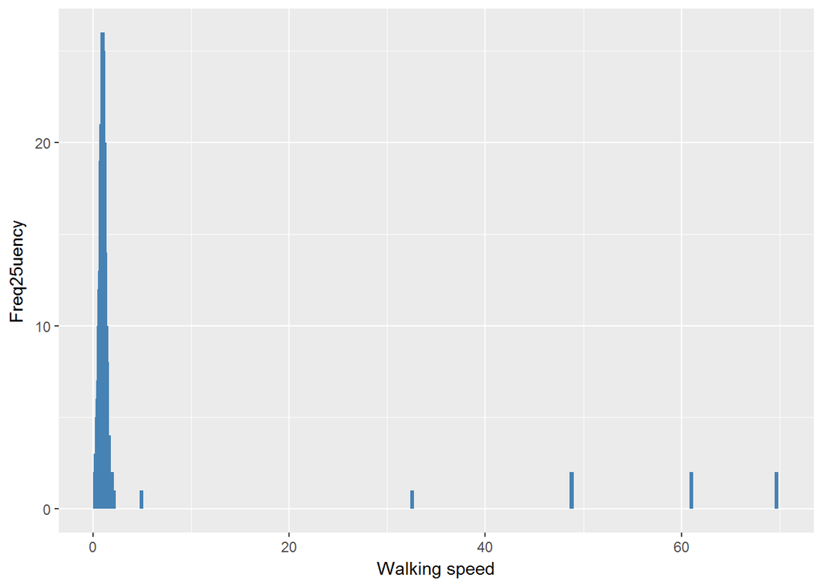

Walking speed

| Sample size | Missing values |
| --- | --- |
| 12099 | 5893 |

Category

|  | 0 | 1 |
| --- | --- | --- |
| Frequency | 1555.00 | 4651.00 |
| Percentage | 12.85 | 38.44 |

Type of missing

|  | 991 | 992 | 993 | 994 | 995 | 996 | 997 | 998 | 999 | NA |
| --- | --- | --- | --- | --- | --- | --- | --- | --- | --- | --- |
| Frequency | 0 | 0 | 0 | 0 | 0 | 5889.00 | 4.00 | 0 | 0 | 0 |
| Percentage | 0 | 0 | 0 | 0 | 0 | 48.67 | 0.03 | 0 | 0 | 0 |

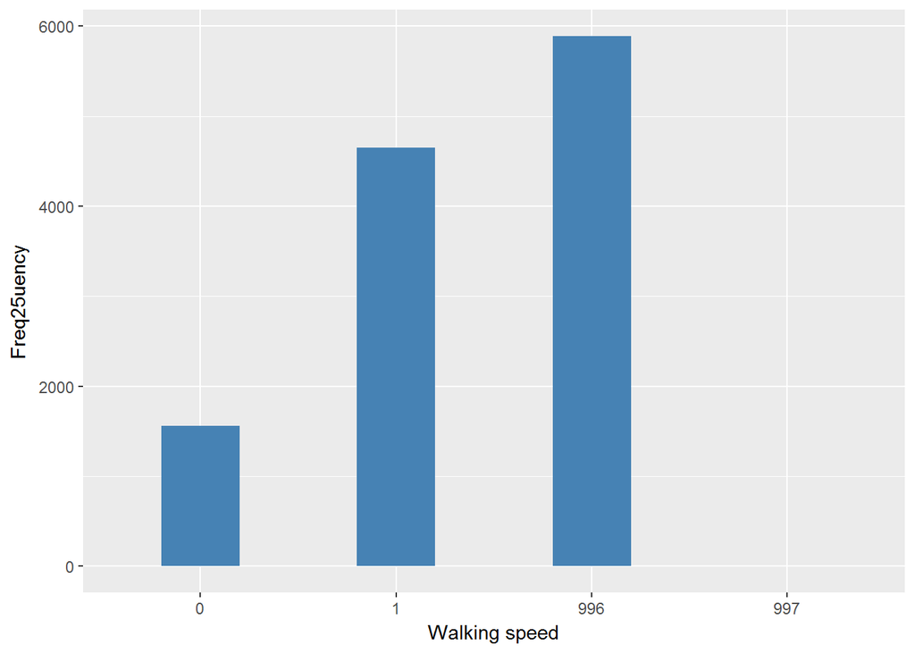

#### 2.1.1.4 Validation

Continuous vs Dichotomous

|  | 0:q25->0 | q25:900->1 | -1->996 | -9->997 |
| --- | --- | --- | --- | --- |
| Continous | 1555 | 4651 | 5889 | 4 |
| Dicotomic | 1555 | 4651 | 5889 | 4 |

ALBERT: I found almost 50% of individuals with “not applicable” missing value. It may come from a skip/jump of a previous variable saying if s/he was available to walk. Actually, this missing values might be re-categorized to “presence of difficulties”.

### 2.1.2 Wave 2

#### 2.1.2.1 Study-specific variable description

| **Name** | `MMWlkA` | `MMWlkB` |
| --- | --- | --- |
| **Label** | `Time taken for first walk (seconds) in a distance of 8 feet (244cm) at their usual walking pace` | `Time taken for second walk (seconds) in a distance of 8 feet (244cm) at their usual walking pace` |
| **Table name** | `wave_2_core_data_v4` | `wave_2_core_data_v4` |
| **Missings** | `-9 = Refusal; -8 = Don't Know; -1 = Not applicable` | `-9 = Refusal; -8 = Don't Know; -1 = Not applicable` |
| **Description** |  |  |

MMWlkA

| Sample size | Missing values |
| --- | --- |
| 9432 | 3898 |

Values

|  | No-missings | -9 | -8 | -1 | NA |
| --- | --- | --- | --- | --- | --- |
| Frequency | 5534.00 | 1.00 | 3.00 | 3894.00 | 0 |
| Percentage | 58.67 | 0.01 | 0.03 | 41.28 | 0 |

Summary

| Min. | 1st Qu. | Median | Mean | 3rd Qu. | Max. |
| --- | --- | --- | --- | --- | --- |
| 1.08 | 2.38 | 2.93 | 3.481 | 3.85 | 30.95 |

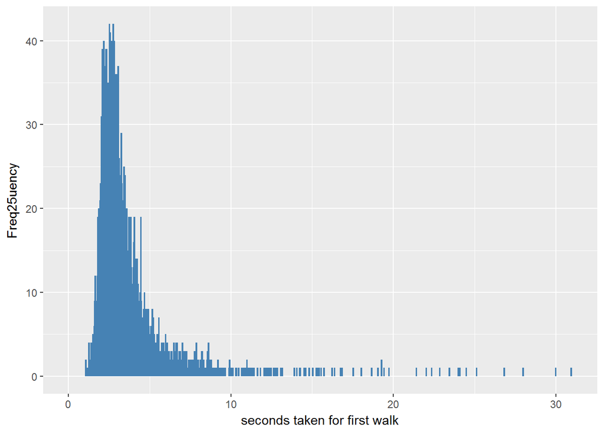

MMWlkB

| Sample size | Missing values |
| --- | --- |
| 9432 | 3920 |

Values

|  | No-missings | -9 | -8 | -1 | NA |
| --- | --- | --- | --- | --- | --- |
| Frequency | 5512.00 | 1.00 | 1.00 | 3918.00 | 0 |
| Percentage | 58.44 | 0.01 | 0.01 | 41.54 | 0 |

Summary

| Min. | 1st Qu. | Median | Mean | 3rd Qu. | Max. |
| --- | --- | --- | --- | --- | --- |
| 1 | 2.29 | 2.82 | 3.321 | 3.64 | 46 |

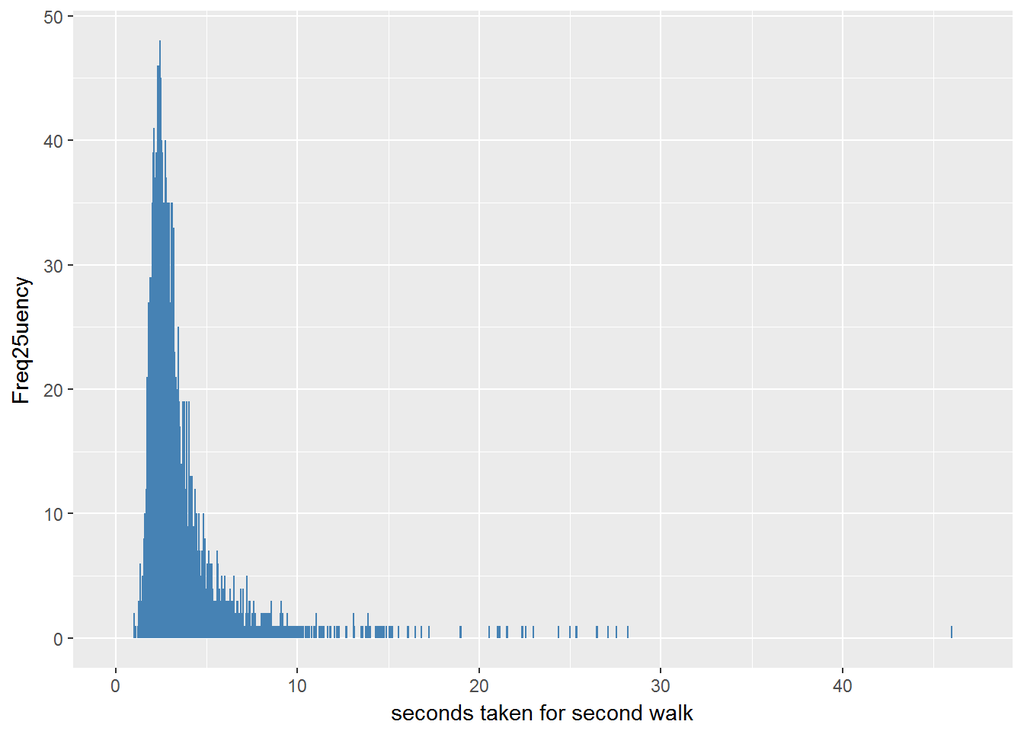

#### 2.1.2.2 Harmonisation algorithm

To compute the harmonize variable `walking_speed_c` from the study-specific variables it has to be computed the mean and recoded as follows:

- `-9 Refusal into 997`
- `-8 Don't Know into 998`
- `-1 Not applicable into 996`
- `NA into 999`

To compute the harmonized variable `walking_speed` from `walking_speed_c` it has to be recoded as follows:

- `walking_speed_c <=25% into 0`
- `walking_speed_c >25% into 1`

**R script:**

```r
ELSA_ds_w2 <- tibble(id = ELSA_w2_walking$id)
n <- length(ELSA_w2_walking$id)
mmwlk <- rep(0, length(ELSA_w2_walking$MMWlkA))
for (i in 1:n) {
    if (ELSA_w2_walking$MMWlkA[i] < 0 & ELSA_w2_walking$MMWlkB[i] >= 0)
        mmwlk[i] <- 2.44/ELSA_w2_walking$MMWlkB[i]

    if (ELSA_w2_walking$MMWlkB[i] < 0 & ELSA_w2_walking$MMWlkA[i] >= 0)
        mmwlk[i] <- 2.44/ELSA_w2_walking$MMWlkA[i]

    if (ELSA_w2_walking$MMWlkA[i] < 0 & ELSA_w2_walking$MMWlkB[i] < 0) {
        mmwlk[i] <- min(ELSA_w2_walking$MMWlkA[i], ELSA_w2_walking$MMWlkB[i])
    }

    if (ELSA_w2_walking$MMWlkA[i] >= 0 & ELSA_w2_walking$MMWlkB[i] >= 0)
        mmwlk[i] <- 2.44/mean(c(ELSA_w2_walking$MMWlkA[i], ELSA_w2_walking$MMWlkB[i]))
}
rm(i)


ELSA_ds_w2$walking_speed_c <- ELSA_ds_w2$walking_speed <- car::recode(as.numeric(unlist(mmwlk)),
    "-9=997; -8=998; -1=996")

ELSA_ds_w2$walking_speed_c <- labelled(ELSA_ds_w2$walking_speed_c, labels = c(Missing = 999,
    `Do not know` = 998, Refuse = 997, `Not applicable` = 996, `Does not answer` = 995,
    `Not attempt not done` = 994, `Disable to measure` = 993, Impute = 992,
    `CAPI interviewer error` = 991))


## cut-off 25% is the R object 'q2525' from wave 1.
q2525 <- quantile(car::recode(ELSA_ds_w2$walking_speed_c, "999=NA; 997=NA; 998=NA; 996=NA"),
    probs = 1/4, na.rm = TRUE, names = FALSE)

ELSA_ds_w2$walking_speed[ELSA_ds_w2$walking_speed_c <= q2525] <- 0
ELSA_ds_w2$walking_speed[ELSA_ds_w2$walking_speed_c > q2525 & ELSA_ds_w2$walking_speed_c <
    990] <- 1
ELSA_ds_w2$walking_speed <- labelled(ELSA_ds_w2$walking_speed, labels = c(`<=25%` = 0,
    `>25%` = 1, Missing = 999, `Do not know` = 998, Refuse = 997, `Not applicable` = 996,
    `Does not answer` = 995, `Not attempt not done` = 994, `Disable to measure` = 993,
    Impute = 992, `CAPI interviewer error` = 991))
```

#### 2.1.2.3 Statistical description of the new harmonised variable

Walking speed

| Sample size | Missing values |
| --- | --- |
| 9432 | 3898 |

Values

|  | No-missings | 991 | 992 | 993 | 994 | 995 | 996 | 997 | 998 | 999 | NA |
| --- | --- | --- | --- | --- | --- | --- | --- | --- | --- | --- | --- |
| Frequency | 5534.00 | 0 | 0 | 0 | 0 | 0 | 3894.00 | 1.00 | 3.00 | 0 | 0 |
| Percentage | 58.67 | 0 | 0 | 0 | 0 | 0 | 41.28 | 0.01 | 0.03 | 0 | 0 |

Summary

| Min. | 1st Qu. | Median | Mean | 3rd Qu. | Max. |
| --- | --- | --- | --- | --- | --- |
| 0.06421 | 0.6524 | 0.848 | 0.8471 | 1.034 | 2.346 |

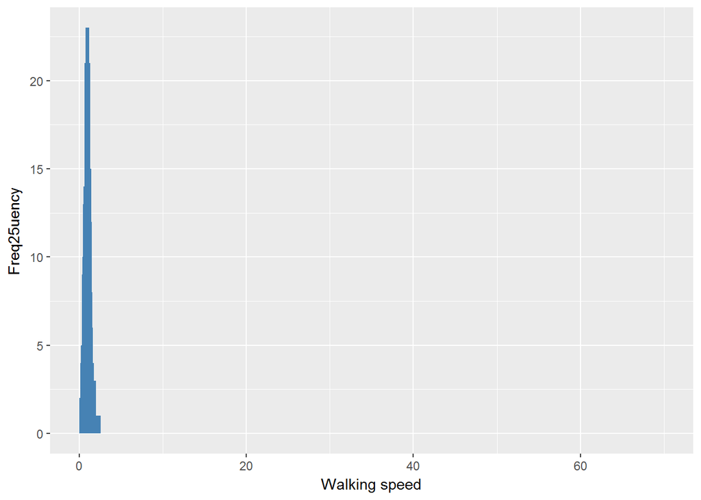

Walking speed

| Sample size | Missing values |
| --- | --- |
| 9432 | 3898 |

Category

|  | 0 | 1 |
| --- | --- | --- |
| Frequency | 1388.00 | 4146.00 |
| Percentage | 14.72 | 43.96 |

Type of missing

|  | 991 | 992 | 993 | 994 | 995 | 996 | 997 | 998 | 999 | NA |
| --- | --- | --- | --- | --- | --- | --- | --- | --- | --- | --- |
| Frequency | 0 | 0 | 0 | 0 | 0 | 3894.00 | 1.00 | 3.00 | 0 | 0 |
| Percentage | 0 | 0 | 0 | 0 | 0 | 41.28 | 0.01 | 0.03 | 0 | 0 |

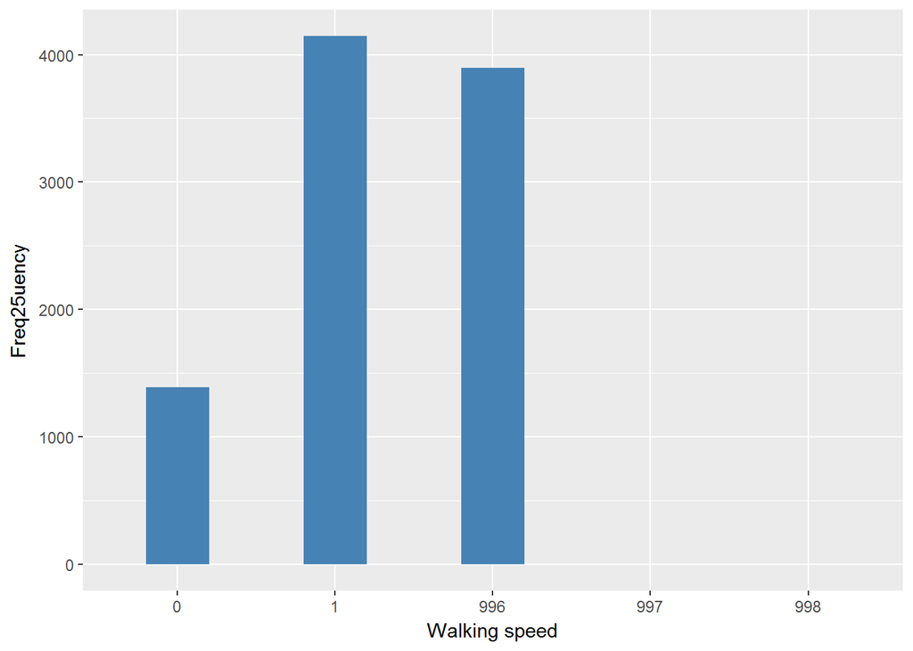

#### 2.1.2.4 Validation

Continuous vs Dichotomous

|  | 0:q25->0 | q25:900->1 | -1->996 | -9->997 | -8->998 |
| --- | --- | --- | --- | --- | --- |
| Continous | 1388 | 4146 | 3894 | 1 | 3 |
| Dicotomic | 1388 | 4146 | 3894 | 1 | 3 |

### 2.1.3 Wave 3

#### 2.1.3.1 Study-specific variable description

| **Name** | `mmwlka` | `mmwlkb` |
| --- | --- | --- |
| **Label** | `Time taken for first walk (seconds) in a distance of 8 feet (244cm) at their usual walking pace` | `Time taken for second walk (seconds) in a distance of 8 feet (244cm) at their usual walking pace` |
| **Table name** | `wave_3_elsa_data_v4` | `wave_3_elsa_data_v4` |
| **Missings** | `-9 = Refusal; -8 = Don't Know; -1 = Not applicable` | `-9 = Refusal; -8 = Don't Know; -1 = Not applicable` |
| **Description** |  |  |

mmwlka

| Sample size | Missing values |
| --- | --- |
| 9771 | 4524 |

Values

|  | No-missings | -9 | -8 | -1 | NA |
| --- | --- | --- | --- | --- | --- |
| Frequency | 5247.0 | 0 | 2.00 | 4522.00 | 0 |
| Percentage | 53.7 | 0 | 0.02 | 46.28 | 0 |

Summary

| Min. | 1st Qu. | Median | Mean | 3rd Qu. | Max. |
| --- | --- | --- | --- | --- | --- |
| 1.06 | 2.4 | 2.97 | 3.551 | 3.88 | 39.83 |

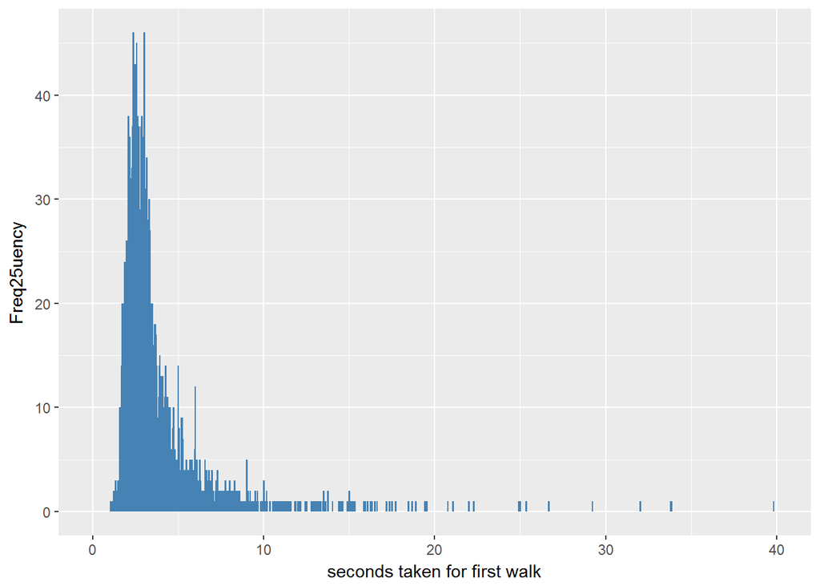

mmwlkb

| Sample size | Missing values |
| --- | --- |
| 9771 | 4531 |

Values

|  | No-missings | -9 | -8 | -1 | NA |
| --- | --- | --- | --- | --- | --- |
| Frequency | 5240.00 | 0 | 1.00 | 4530.00 | 0 |
| Percentage | 53.63 | 0 | 0.01 | 46.36 | 0 |

Summary

| Min. | 1st Qu. | Median | Mean | 3rd Qu. | Max. |
| --- | --- | --- | --- | --- | --- |
| 1 | 2.31 | 2.83 | 3.402 | 3.69 | 38.01 |

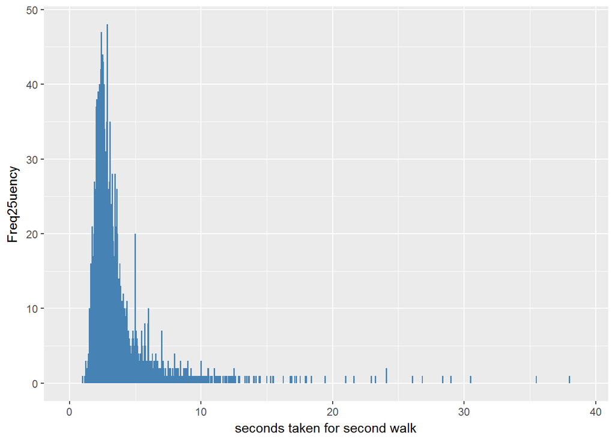

#### 2.1.3.2 Harmonisation algorithm

To compute the harmonize variable from the study-specific variable it has to be recoded as follows:

- `-9 Refusal into 997`
- `-8 Don't know into 998`
- `-1 Not applicable into 996`

**R script:**

```r
ELSA_ds_w3 <- tibble(id = ELSA_w3_walking$id)
n <- length(ELSA_w3_walking$id)
mmwlk <- rep(0, length(ELSA_w3_walking$mmwlka))
for (i in 1:n) {
    if (ELSA_w3_walking$mmwlka[i] < 0 & ELSA_w3_walking$mmwlkb[i] >= 0)
        mmwlk[i] <- 2.44/ELSA_w3_walking$mmwlkb[i]

    if (ELSA_w3_walking$mmwlkb[i] < 0 & ELSA_w3_walking$mmwlka[i] >= 0)
        mmwlk[i] <- 2.44/ELSA_w3_walking$mmwlka[i]

    if (ELSA_w3_walking$mmwlka[i] < 0 & ELSA_w3_walking$mmwlkb[i] < 0) {
        mmwlk[i] <- min(ELSA_w3_walking$mmwlka[i], ELSA_w3_walking$mmwlkb[i])
    }

    if (ELSA_w3_walking$mmwlka[i] >= 0 & ELSA_w3_walking$mmwlkb[i] >= 0)
        mmwlk[i] <- 2.44/mean(c(ELSA_w3_walking$mmwlka[i], ELSA_w3_walking$mmwlkb[i]))
}
rm(i)




ELSA_ds_w3$walking_speed <- ELSA_ds_w3$walking_speed_c <- car::recode(as.numeric(unlist(mmwlk)),
    "-9 = '997';-8 = '998';-1 = '996' ")

ELSA_ds_w3$walking_speed_c <- labelled(ELSA_ds_w3$walking_speed_c, labels = c(Missing = 999,
    `Do not know` = 998, Refuse = 997, `Not applicable` = 996, `Does not answer` = 995,
    `Not attempt not done` = 994, `Disable to measure` = 993, Impute = 992,
    `CAPI interviewer error` = 991))


## cut-off 25% is the R object 'q2525' from wave 1.
q2525 <- quantile(car::recode(ELSA_ds_w3$walking_speed_c, "999=NA; 997=NA; 998=NA; 996=NA"),
    probs = 1/4, na.rm = TRUE, names = FALSE)

ELSA_ds_w3$walking_speed[ELSA_ds_w3$walking_speed_c <= q2525] <- 0
ELSA_ds_w3$walking_speed[ELSA_ds_w3$walking_speed_c > q2525 & ELSA_ds_w3$walking_speed_c <
    990] <- 1
ELSA_ds_w3$walking_speed <- labelled(ELSA_ds_w3$walking_speed, labels = c(`<=25%` = 0,
    `>25%` = 1, Missing = 999, `Do not know` = 998, Refuse = 997, `Not applicable` = 996,
    `Does not answer` = 995, `Not attempt not done` = 994, `Disable to measure` = 993,
    Impute = 992, `CAPI interviewer error` = 991))
```

#### 2.1.3.3 Statistical description of the new harmonised variable

Walking speed

| Sample size | Missing values |
| --- | --- |
| 9771 | 4523 |

Values

|  | No-missings | 991 | 992 | 993 | 994 | 995 | 996 | 997 | 998 | 999 | NA |
| --- | --- | --- | --- | --- | --- | --- | --- | --- | --- | --- | --- |
| Frequency | 5248.00 | 0 | 0 | 0 | 0 | 0 | 4522.00 | 0 | 1.00 | 0 | 0 |
| Percentage | 53.71 | 0 | 0 | 0 | 0 | 0 | 46.28 | 0 | 0.01 | 0 | 0 |

Summary

| Min. | 1st Qu. | Median | Mean | 3rd Qu. | Max. |
| --- | --- | --- | --- | --- | --- |
| 0.06479 | 0.6453 | 0.8428 | 0.8405 | 1.032 | 2.188 |

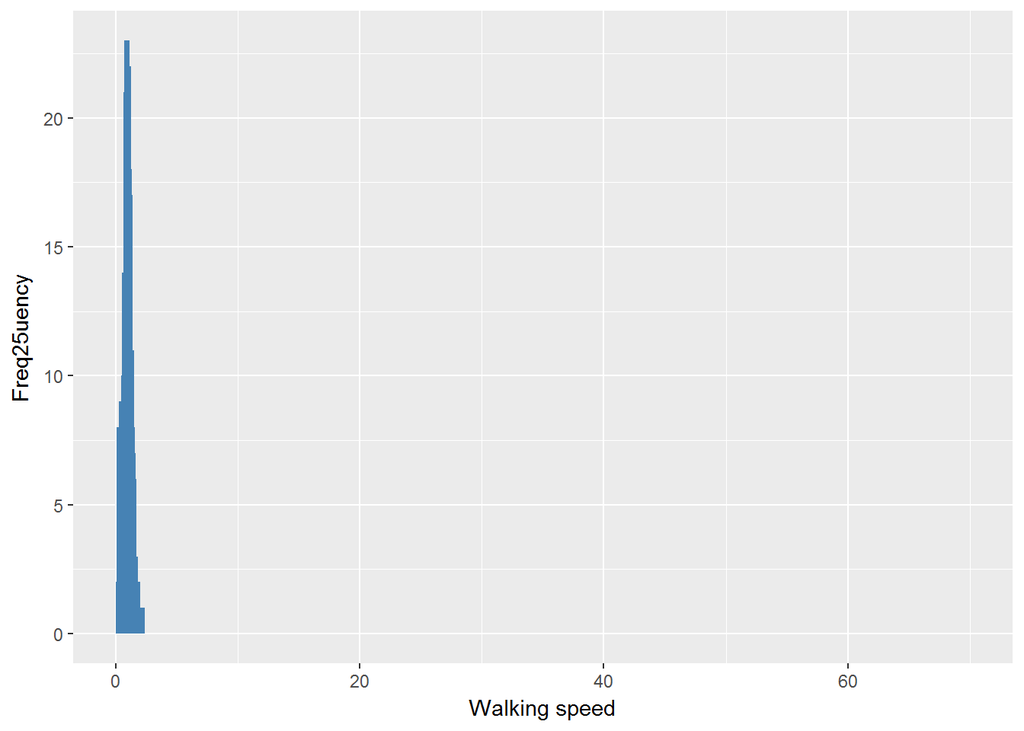

Walking speed

| Sample size | Missing values |
| --- | --- |
| 9771 | 4523 |

Category

|  | 0 | 1 |
| --- | --- | --- |
| Frequency | 1312.00 | 3936.00 |
| Percentage | 13.43 | 40.28 |

Type of missing

|  | 991 | 992 | 993 | 994 | 995 | 996 | 997 | 998 | 999 | NA |
| --- | --- | --- | --- | --- | --- | --- | --- | --- | --- | --- |
| Frequency | 0 | 0 | 0 | 0 | 0 | 4522.00 | 0 | 1.00 | 0 | 0 |
| Percentage | 0 | 0 | 0 | 0 | 0 | 46.28 | 0 | 0.01 | 0 | 0 |

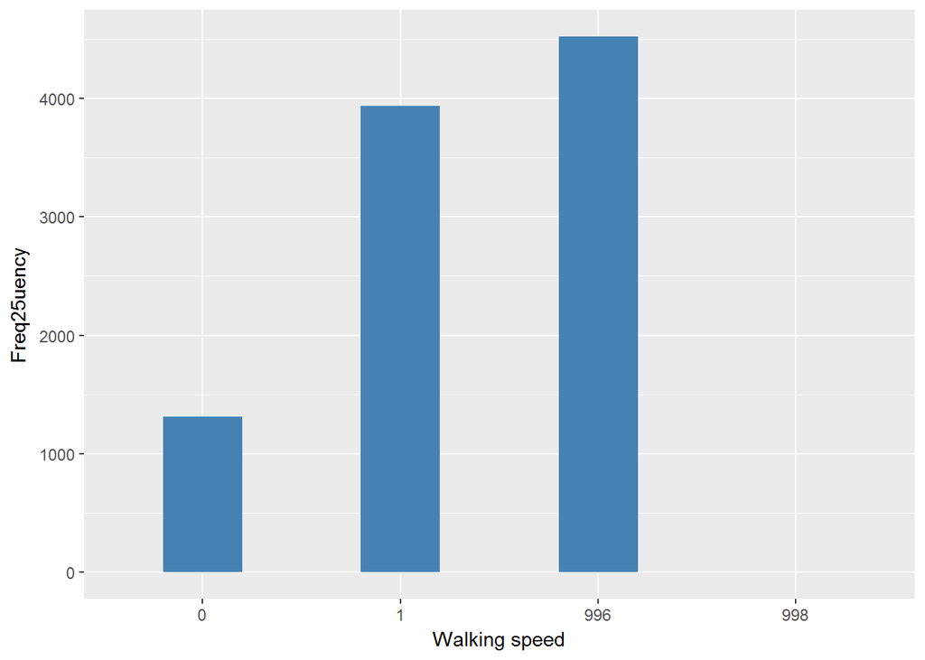

#### 2.1.3.4 Validation

Continuous vs Dichotomous

[output not shown]

### 2.1.4 Wave 4

#### 2.1.4.1 Study-specific variable description

| **Name** | `mmwlka` | `mmwlkb` |
| --- | --- | --- |
| **Label** | `Time taken for first walk (seconds) in a distance of 8 feet (244cm) at their usual walking pace` | `Time taken for second walk (seconds) in a distance of 8 feet (244cm) at their usual walking pace` |
| **Table name** | `wave_4_elsa_data_v3` | `wave_4_elsa_data_v3` |
| **Missings** | `-9 = Refusal; -8 = Don't Know; -1 = Not applicable` | `-9 = Refusal; -8 = Don't Know; -1 = Not applicable` |
| **Description** |  |  |

mmwlka

| Sample size | Missing values |
| --- | --- |
| 11050 | 4757 |

Values

|  | No-missings | -9 | -8 | -1 | NA |
| --- | --- | --- | --- | --- | --- |
| Frequency | 6293.00 | 1.00 | 5.00 | 4751 | 0 |
| Percentage | 56.95 | 0.01 | 0.05 | 43 | 0 |

Summary

| Min. | 1st Qu. | Median | Mean | 3rd Qu. | Max. |
| --- | --- | --- | --- | --- | --- |
| -2 | 2.35 | 2.9 | 3.389 | 3.74 | 37.07 |

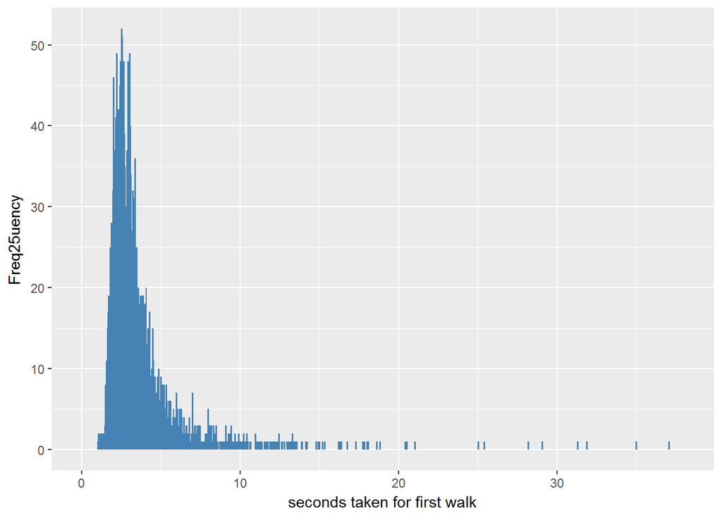

mmwlkb

| Sample size | Missing values |
| --- | --- |
| 11050 | 4762 |

Values

|  | No-missings | -9 | -8 | -1 | NA |
| --- | --- | --- | --- | --- | --- |
| Frequency | 6288.0 | 0 | 0 | 4762.0 | 0 |
| Percentage | 56.9 | 0 | 0 | 43.1 | 0 |

Summary

| Min. | 1st Qu. | Median | Mean | 3rd Qu. | Max. |
| --- | --- | --- | --- | --- | --- |
| -2 | 2.26 | 2.77 | 3.236 | 3.55 | 41.13 |

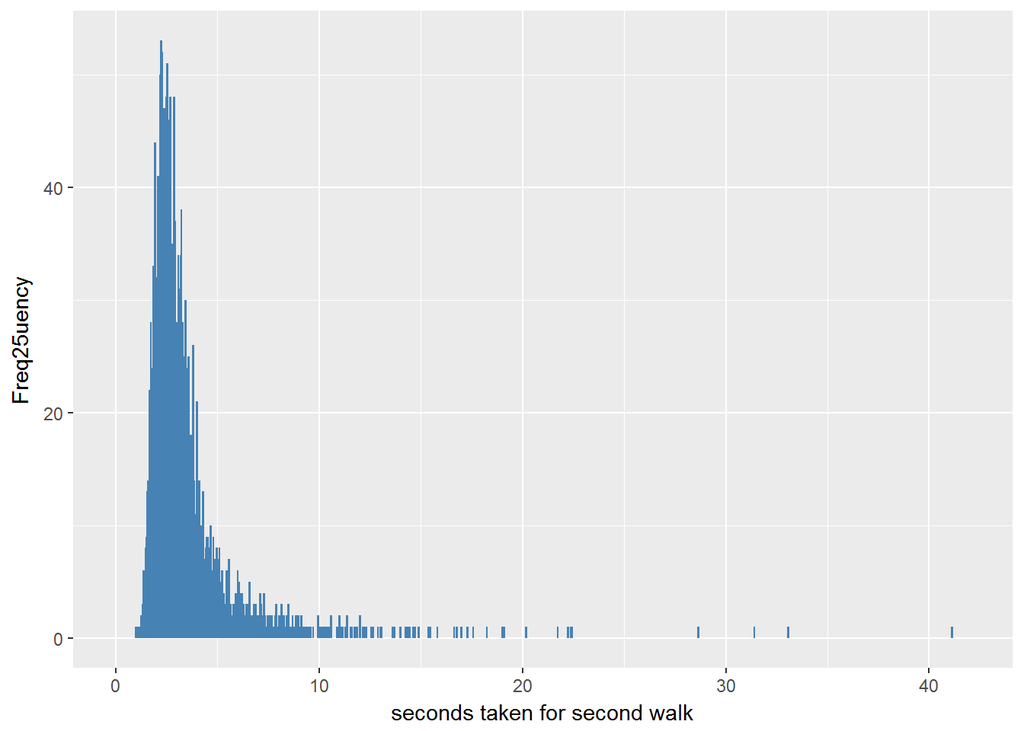

#### 2.1.4.2 Harmonisation algorithm

To compute the harmonize variable `walking_speed_c` from the study-specific variables it has to be computed the mean and recoded as follows:

- `-9 Refusal into 997`
- `-8 Don't Know into 998`
- `-1 Not applicable into 996`
- `NA into 999`

To compute the harmonized variable `walking_speed` from `walking_speed_c` it has to be recoded as follows:

- `walking_speed_c <=25% into 0`
- `walking_speed_c >25% into 1`

**R script:**

```r
ELSA_ds_w4 <- tibble(id = ELSA_w4_walking$id)
n <- length(ELSA_w4_walking$id)
mmwlk <- rep(0, length(ELSA_w4_walking$mmwlka))
for (i in 1:n) {
    if (ELSA_w4_walking$mmwlka[i] < 0 & ELSA_w4_walking$mmwlkb[i] >= 0)
        mmwlk[i] <- 2.44/ELSA_w4_walking$mmwlkb[i]

    if (ELSA_w4_walking$mmwlkb[i] < 0 & ELSA_w4_walking$mmwlka[i] >= 0)
        mmwlk[i] <- 2.44/ELSA_w4_walking$mmwlka[i]

    if (ELSA_w4_walking$mmwlka[i] < 0 & ELSA_w4_walking$mmwlkb[i] < 0) {
        mmwlk[i] <- min(ELSA_w4_walking$mmwlka[i], ELSA_w4_walking$mmwlkb[i])
    }

    if (ELSA_w4_walking$mmwlka[i] >= 0 & ELSA_w4_walking$mmwlkb[i] >= 0)
        mmwlk[i] <- 2.44/mean(c(ELSA_w4_walking$mmwlka[i], ELSA_w4_walking$mmwlkb[i]))
}
rm(i)




ELSA_ds_w4$walking_speed <- ELSA_ds_w4$walking_speed_c <- car::recode(as.numeric(unlist(mmwlk)),
    "-9 = '997';-8 = '998';-1 = '996';-2 = '991' ")

ELSA_ds_w4$walking_speed_c <- labelled(ELSA_ds_w4$walking_speed_c, labels = c(Missing = 999,
    `Do not know` = 998, Refuse = 997, `Not applicable` = 996, `Does not answer` = 995,
    `Not attempt not done` = 994, `Disable to measure` = 993, Impute = 992,
    `CAPI interviewer error` = 991))


## cut-off 25% is the R object 'q252525' from wave 1.

ELSA_ds_w4$walking_speed[ELSA_ds_w4$walking_speed_c <= q25] <- 0
ELSA_ds_w4$walking_speed[ELSA_ds_w4$walking_speed_c > q25 & ELSA_ds_w4$walking_speed_c <
    990] <- 1
ELSA_ds_w4$walking_speed <- labelled(ELSA_ds_w4$walking_speed, labels = c(`<=25%` = 0,
    `>25%` = 1, Missing = 999, `Do not know` = 998, Refuse = 997, `Not applicable` = 996,
    `Does not answer` = 995, `Not attempt not done` = 994, `Disable to measure` = 993,
    Impute = 992, `CAPI interviewer error` = 991))
```

#### 2.1.4.3 Statistical description of the new harmonised variable

Walking speed

| Sample size | Missing values |
| --- | --- |
| 11050 | 4758 |

Values

|  | No-missings | 991 | 992 | 993 | 994 | 995 | 996 | 997 | 998 | 999 | NA |
| --- | --- | --- | --- | --- | --- | --- | --- | --- | --- | --- | --- |
| Frequency | 6292.00 | 1.00 | 0 | 0 | 0 | 0 | 4751 | 1.00 | 5.00 | 0 | 0 |
| Percentage | 56.94 | 0.01 | 0 | 0 | 0 | 0 | 43 | 0.01 | 0.05 | 0 | 0 |

Summary

| Min. | 1st Qu. | Median | Mean | 3rd Qu. | Max. |
| --- | --- | --- | --- | --- | --- |
| 0.06582 | 0.6713 | 0.8622 | 0.8636 | 1.052 | 2.27 |

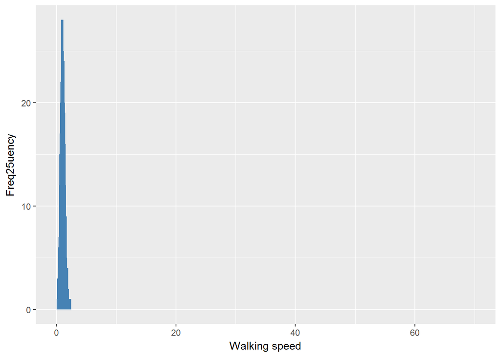

Walking speed

| Sample size | Missing values |
| --- | --- |
| 11050 | 4758 |

Category

|  | 0 | 1 |
| --- | --- | --- |
| Frequency | 1318.00 | 4974.00 |
| Percentage | 11.93 | 45.01 |

Type of missing

|  | 991 | 992 | 993 | 994 | 995 | 996 | 997 | 998 | 999 | NA |
| --- | --- | --- | --- | --- | --- | --- | --- | --- | --- | --- |
| Frequency | 1.00 | 0 | 0 | 0 | 0 | 4751 | 1.00 | 5.00 | 0 | 0 |
| Percentage | 0.01 | 0 | 0 | 0 | 0 | 43 | 0.01 | 0.05 | 0 | 0 |

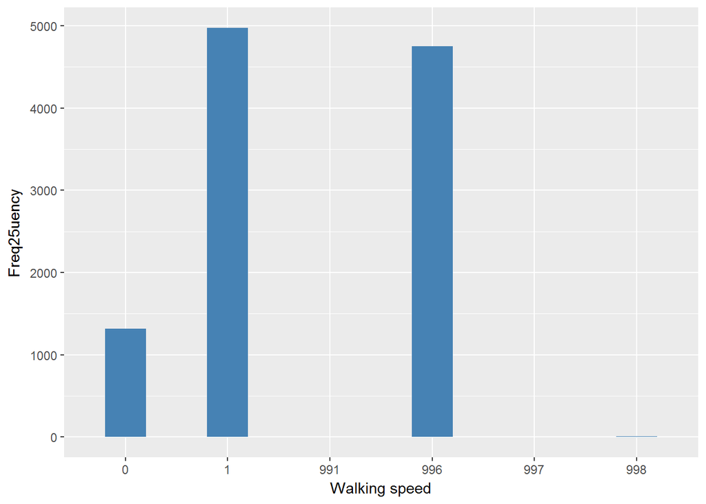

#### 2.1.4.4 Validation

Continuous vs Dichotomous

|  | 0:q25->0 | q25:900->1 | -2->991 | -1->996 | -9->997 | -8->998 |
| --- | --- | --- | --- | --- | --- | --- |
| Continous | 1318 | 4974 | 1 | 4751 | 1 | 5 |
| Dicotomic | 1318 | 4974 | 1 | 4751 | 1 | 5 |

### 2.1.5 Wave 5

#### 2.1.5.1 Study-specific variable description

| **Name** | `mmwlka` | `mmwlkb` |
| --- | --- | --- |
| **Label** | `Time taken for first walk (seconds) in a distance of 8 feet (244cm) at their usual walking pace` | `Time taken for second walk (seconds) in a distance of 8 feet (244cm) at their usual walking pace` |
| **Table name** | `wave_5_elsa_data_v4` | `wave_5_elsa_data_v4` |
| **Missings** | `-8 = Don't Know; -1 = Not applicable` | `-8 = Don't Know; -1 = Not applicable` |
| **Description** |  |  |

mmwlka

| Sample size | Missing values |
| --- | --- |
| 10274 | 3851 |

Values

|  | No-missings | -9 | -8 | -1 | NA |
| --- | --- | --- | --- | --- | --- |
| Frequency | 6423.00 | 0 | 1.00 | 3850.00 | 0 |
| Percentage | 62.52 | 0 | 0.01 | 37.47 | 0 |

Summary

| Min. | 1st Qu. | Median | Mean | 3rd Qu. | Max. |
| --- | --- | --- | --- | --- | --- |
| 1 | 2.31 | 2.81 | 3.266 | 3.55 | 38.78 |

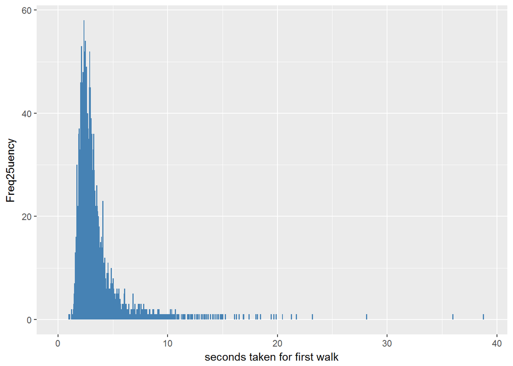

mmwlkb

| Sample size | Missing values |
| --- | --- |
| 10274 | 3861 |

Values

|  | No-missings | -9 | -8 | -1 | NA |
| --- | --- | --- | --- | --- | --- |
| Frequency | 6413.00 | 0 | 1.00 | 3860.00 | 0 |
| Percentage | 62.42 | 0 | 0.01 | 37.57 | 0 |

Summary

| Min. | 1st Qu. | Median | Mean | 3rd Qu. | Max. |
| --- | --- | --- | --- | --- | --- |
| 1.08 | 2.23 | 2.68 | 3.129 | 3.38 | 41.51 |

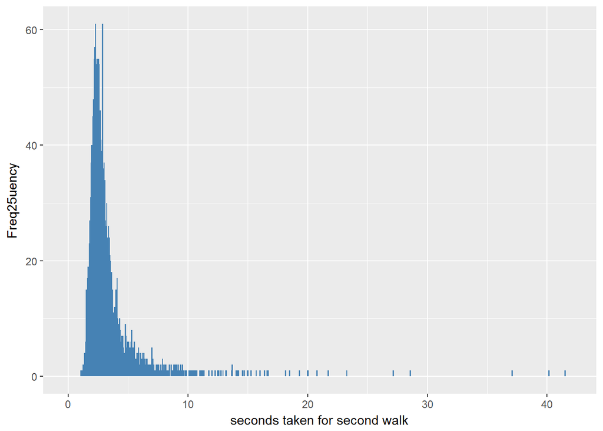

#### 2.1.5.2 Harmonisation algorithm

To compute the harmonize variable `walking_speed_c` from the study-specific variables it has to be computed the mean and recoded as follows:

- `-8 Don't Know into 998`
- `-1 Not applicable into 996`
- `NA into 999`

To compute the harmonized variable `walking_speed` from `walking_speed_c` it has to be recoded as follows:

- `walking_speed_c <=25% into 0`
- `walking_speed_c >25% into 1`

**R script:**

**R script:**

```r
ELSA_ds_w5 <- tibble(id = ELSA_w5_walking$id)
n <- length(ELSA_w5_walking$id)
mmwlk <- rep(0, length(ELSA_w5_walking$mmwlka))
for (i in 1:n) {
    if (ELSA_w5_walking$mmwlka[i] < 0 & ELSA_w5_walking$mmwlkb[i] >= 0)
        mmwlk[i] <- 2.44/ELSA_w5_walking$mmwlkb[i]

    if (ELSA_w5_walking$mmwlkb[i] < 0 & ELSA_w5_walking$mmwlka[i] >= 0)
        mmwlk[i] <- 2.44/ELSA_w5_walking$mmwlka[i]

    if (ELSA_w5_walking$mmwlka[i] < 0 & ELSA_w5_walking$mmwlkb[i] < 0) {
        mmwlk[i] <- min(ELSA_w5_walking$mmwlka[i], ELSA_w5_walking$mmwlkb[i])
    }

    if (ELSA_w5_walking$mmwlka[i] >= 0 & ELSA_w5_walking$mmwlkb[i] >= 0)
        mmwlk[i] <- 2.44/mean(c(ELSA_w5_walking$mmwlka[i], ELSA_w5_walking$mmwlkb[i]))
}
rm(i)




ELSA_ds_w5$walking_speed <- ELSA_ds_w5$walking_speed_c <- car::recode(as.numeric(unlist(mmwlk)),
    "-8 = '998';-1 = '996' ")
ELSA_ds_w5$walking_speed_c <- labelled(ELSA_ds_w5$walking_speed_c, labels = c(Missing = 999,
    `Do not know` = 998, Refuse = 997, `Not applicable` = 996, `Does not answer` = 995,
    `Not attempt not done` = 994, `Disable to measure` = 993, Impute = 992,
    `CAPI interviewer error` = 991))

## cut-off 25% is the R object 'q25' from wave 1.
q25 <- quantile(car::recode(ELSA_ds_w5$walking_speed_c, "999=NA; 997=NA; 998=NA; 996=NA"),
    probs = 1/4, na.rm = TRUE, names = FALSE)

ELSA_ds_w5$walking_speed[ELSA_ds_w5$walking_speed_c <= q25] <- 0
ELSA_ds_w5$walking_speed[ELSA_ds_w5$walking_speed_c > q25 & ELSA_ds_w5$walking_speed_c <
    990] <- 1

ELSA_ds_w5$walking_speed <- labelled(ELSA_ds_w5$walking_speed, labels = c(`<=25%` = 0,
    `>25%` = 1, Missing = 999, `Do not know` = 998, Refuse = 997, `Not applicable` = 996,
    `Does not answer` = 995, `Not attempt not done` = 994, `Disable to measure` = 993,
    Impute = 992, `CAPI interviewer error` = 991))
```

#### 2.1.5.3 Statistical description of the new harmonised variable

Walking speed

| Sample size | Missing values |
| --- | --- |
| 10274 | 3851 |

Values

|  | No-missings | 991 | 992 | 993 | 994 | 995 | 996 | 997 | 998 | 999 | NA |
| --- | --- | --- | --- | --- | --- | --- | --- | --- | --- | --- | --- |
| Frequency | 6423.00 | 0 | 0 | 0 | 0 | 0 | 3850.00 | 0 | 1.00 | 0 | 0 |
| Percentage | 62.52 | 0 | 0 | 0 | 0 | 0 | 37.47 | 0 | 0.01 | 0 | 0 |

Summary

| Min. | 1st Qu. | Median | Mean | 3rd Qu. | Max. |
| --- | --- | --- | --- | --- | --- |
| 0.06183 | 0.7047 | 0.8889 | 0.8856 | 1.068 | 2.28 |

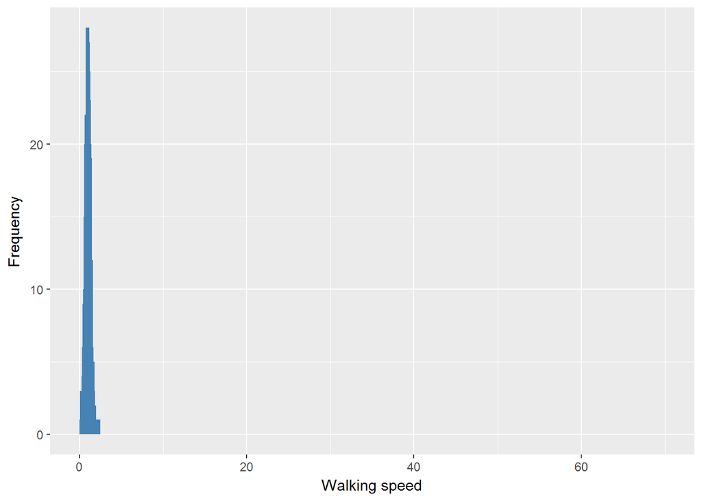

Walking speed

| Sample size | Missing values |
| --- | --- |
| 10274 | 3851 |

Category

|  | 0 | 1 |
| --- | --- | --- |
| Frequency | 1606.00 | 4817.00 |
| Percentage | 15.63 | 46.89 |

Type of missing

|  | 991 | 992 | 993 | 994 | 995 | 996 | 997 | 998 | 999 | NA |
| --- | --- | --- | --- | --- | --- | --- | --- | --- | --- | --- |
| Frequency | 0 | 0 | 0 | 0 | 0 | 3850.00 | 0 | 1.00 | 0 | 0 |
| Percentage | 0 | 0 | 0 | 0 | 0 | 37.47 | 0 | 0.01 | 0 | 0 |

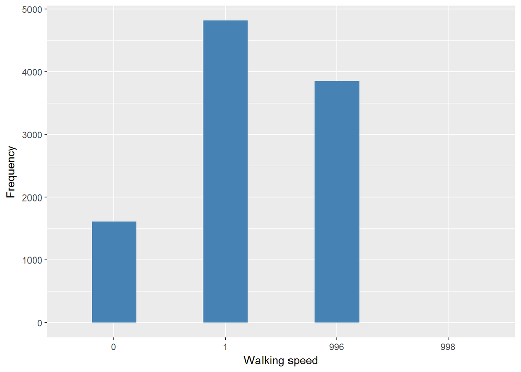

#### 2.1.5.4 Validation

Continuous vs Dichotomous

|  | 0:q25->0 | q25:900->1 | -1->996 | -8->998 |
| --- | --- | --- | --- | --- |
| Continous | 1606 | 4817 | 3850 | 1 |
| Dicotomic | 1606 | 4817 | 3850 | 1 |

### 2.1.6 Wave 6

#### 2.1.6.1 Study-specific variable description

| **Name** | `MMWlkA` | `MMWlkB` |
| --- | --- | --- |
| **Label** | `Time taken for first walk (seconds) in a distance of 8 feet (244cm) at their usual walking pace` | `Time taken for second walk (seconds) in a distance of 8 feet (244cm) at their usual walking pace` |
| **Table name** | `wave_6_elsa_data_v2` | `wave_6_elsa_data_v2` |
| **Missings** | `-8 = Don't Know; -1 = Not applicable` | `-8 = Don't Know; -1 = Not applicable` |
| **Description** |  |  |

MMWlkA

| Sample size | Missing values |
| --- | --- |
| 10601 | 4147 |

Values

|  | No-missings | -8 | -1 | NA |
| --- | --- | --- | --- | --- |
| Frequency | 6454.00 | 1.00 | 4146.00 | 0 |
| Percentage | 60.88 | 0.01 | 39.11 | 0 |

Summary

| Min. | 1st Qu. | Median | Mean | 3rd Qu. | Max. |
| --- | --- | --- | --- | --- | --- |
| 1 | 2.29 | 2.77 | 3.221 | 3.49 | 46.47 |

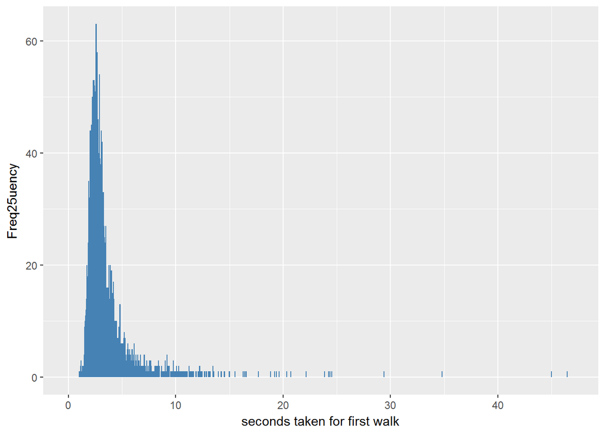

MMWlkB

| Sample size | Missing values |
| --- | --- |
| 10601 | 4158 |

Values

|  | No-missings | -8 | -1 | NA |
| --- | --- | --- | --- | --- |
| Frequency | 6443.00 | 2.00 | 4156.0 | 0 |
| Percentage | 60.78 | 0.02 | 39.2 | 0 |

Summary

| Min. | 1st Qu. | Median | Mean | 3rd Qu. | Max. |
| --- | --- | --- | --- | --- | --- |
| 1 | 2.24 | 2.67 | 3.102 | 3.35 | 44.78 |

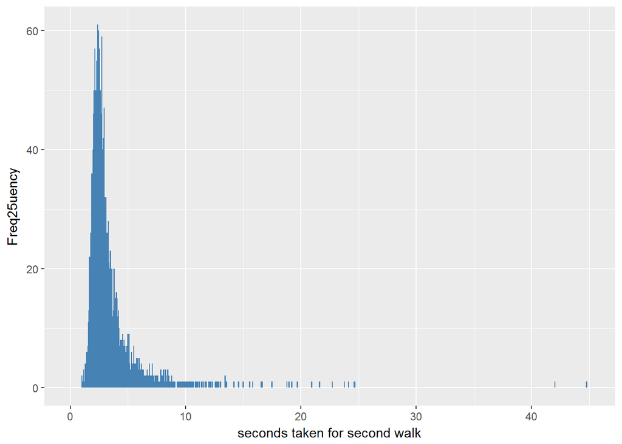

#### 2.1.6.2 Harmonisation algorithm

To compute the harmonize variable `walking_speed_c` from the study-specific variables it has to be computed the mean and recoded as follows:

- `-8 Don't Know into 998`
- `-1 Not applicable into 996`
- `NA into 999`

To compute the harmonized variable `walking_speed` from `walking_speed_c` it has to be recoded as follows:

- `walking_speed_c <=25% into 0`
- `walking_speed_c >25% into 1`

**R script:**

```r
ELSA_ds_w6 <- tibble(id = ELSA_w6_walking$id)
n <- length(ELSA_w6_walking$id)
mmwlk <- rep(0, length(ELSA_w6_walking$MMWlkA))
for (i in 1:n) {
    if (ELSA_w6_walking$MMWlkA[i] < 0 & ELSA_w6_walking$MMWlkB[i] >= 0)
        mmwlk[i] <- 2.44/ELSA_w6_walking$MMWlkB[i]

    if (ELSA_w6_walking$MMWlkB[i] < 0 & ELSA_w6_walking$MMWlkA[i] >= 0)
        mmwlk[i] <- 2.44/ELSA_w6_walking$MMWlkA[i]

    if (ELSA_w6_walking$MMWlkA[i] < 0 & ELSA_w6_walking$MMWlkB[i] < 0) {
        mmwlk[i] <- min(ELSA_w6_walking$MMWlkA[i], ELSA_w6_walking$MMWlkB[i])
    }

    if (ELSA_w6_walking$MMWlkA[i] >= 0 & ELSA_w6_walking$MMWlkB[i] >= 0)
        mmwlk[i] <- 2.44/mean(c(ELSA_w6_walking$MMWlkA[i], ELSA_w6_walking$MMWlkB[i]))
}
rm(i)




ELSA_ds_w6$walking_speed <- ELSA_ds_w6$walking_speed_c <- car::recode(as.numeric(unlist(mmwlk)),
    "-8 = '998';-1 = '996' ")

ELSA_ds_w6$walking_speed_c <- labelled(ELSA_ds_w6$walking_speed_c, labels = c(Missing = 999,
    `Do not know` = 998, Refuse = 997, `Not applicable` = 996, `Does not answer` = 995,
    `Not attempt not done` = 994, `Disable to measure` = 993, Impute = 992,
    `CAPI interviewer error` = 991))


## cut-off 25% is the R object 'q25' from wave 1.
q25 <- quantile(car::recode(ELSA_ds_w6$walking_speed_c, "999=NA; 997=NA; 998=NA; 996=NA"),
    probs = 1/4, na.rm = TRUE, names = FALSE)

ELSA_ds_w6$walking_speed[ELSA_ds_w6$walking_speed_c <= q25] <- 0
ELSA_ds_w6$walking_speed[ELSA_ds_w6$walking_speed_c > q25 & ELSA_ds_w6$walking_speed_c <
    990] <- 1

ELSA_ds_w6$walking_speed <- labelled(ELSA_ds_w6$walking_speed, labels = c(`<=25%` = 0,
    `>25%` = 1, Missing = 999, `Do not know` = 998, Refuse = 997, `Not applicable` = 996,
    `Does not answer` = 995, `Not attempt not done` = 994, `Disable to measure` = 993,
    Impute = 992, `CAPI interviewer error` = 991))
```

#### 2.1.6.3 Statistical description of the new harmonised variable

Walking speed

| Sample size | Missing values |
| --- | --- |
| 10601 | 4147 |

Values

|  | No-missings | 991 | 992 | 993 | 994 | 995 | 996 | 997 | 998 | 999 | NA |
| --- | --- | --- | --- | --- | --- | --- | --- | --- | --- | --- | --- |
| Frequency | 6454.00 | 0 | 0 | 0 | 0 | 0 | 4146.00 | 0 | 1.00 | 0 | 0 |
| Percentage | 60.88 | 0 | 0 | 0 | 0 | 0 | 39.11 | 0 | 0.01 | 0 | 0 |

Summary

| Min. | 1st Qu. | Median | Mean | 3rd Qu. | Max. |
| --- | --- | --- | --- | --- | --- |
| 0.05436 | 0.7137 | 0.8971 | 0.8916 | 1.07 | 2.44 |

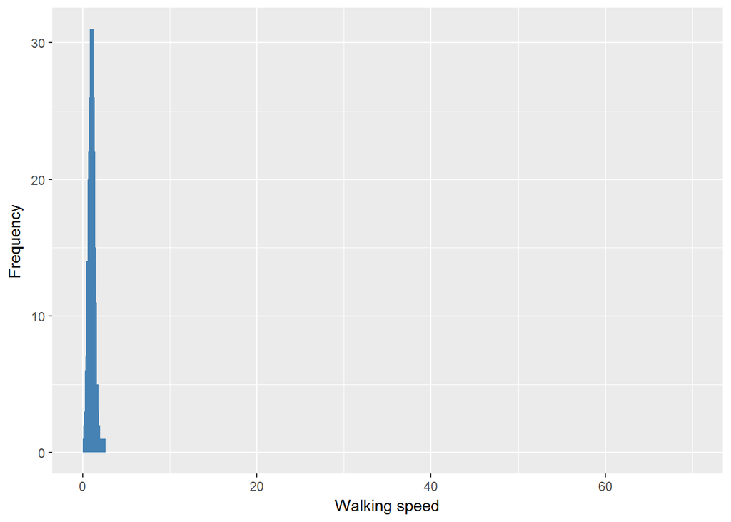

Walking speed

| Sample size | Missing values |
| --- | --- |
| 10601 | 4147 |

Category

|  | 0 | 1 |
| --- | --- | --- |
| Frequency | 1614.00 | 4840.00 |
| Percentage | 15.22 | 45.66 |

Type of missing

|  | 991 | 992 | 993 | 994 | 995 | 996 | 997 | 998 | 999 | NA |
| --- | --- | --- | --- | --- | --- | --- | --- | --- | --- | --- |
| Frequency | 0 | 0 | 0 | 0 | 0 | 4146.00 | 0 | 1.00 | 0 | 0 |
| Percentage | 0 | 0 | 0 | 0 | 0 | 39.11 | 0 | 0.01 | 0 | 0 |

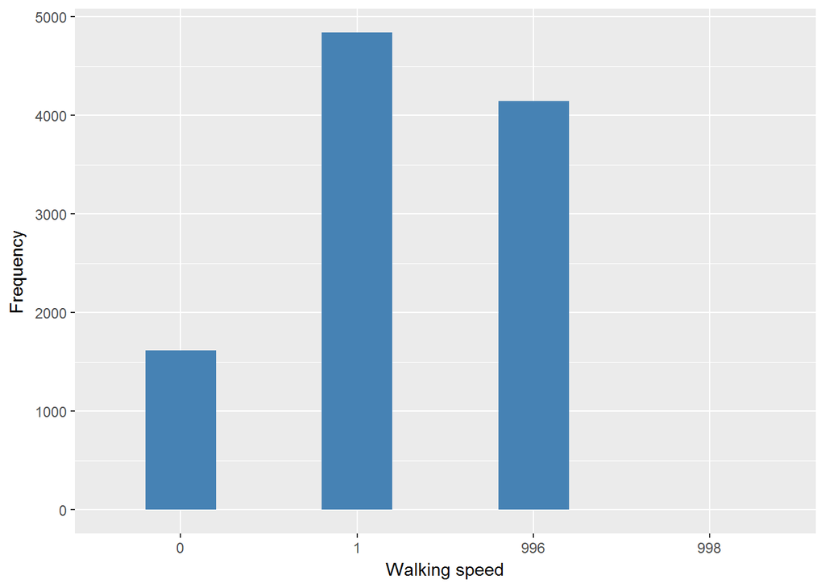

#### 2.1.6.4 Validation

Continuous vs Dichotomous

|  | 0:q25->0 | q25:900->1 | -1->996 | -8->998 |
| --- | --- | --- | --- | --- |
| Continous | 1614 | 4840 | 4146 | 1 |
| Dicotomic | 1614 | 4840 | 4146 | 1 |

### 2.1.7 Wave 7

#### 2.1.7.1 Study-specific variable description

| **Name** | `MMWlkA` | `MMWlkB` |
| --- | --- | --- |
| **Label** | `Time taken for first walk (seconds) in a distance of 8 feet (244cm) at their usual walking pace` | `Time taken for second walk (seconds) in a distance of 8 feet (244cm) at their usual walking pace` |
| **Table name** | `wave_7_elsa_data` | `wave_7_elsa_data` |
| **Missings** | `-8 = Don't Know; -1 = Not applicable` | `-8 = Don't Know; -1 = Not applicable` |
| **Description** |  |  |

MMWlkA

| Sample size | Missing values |
| --- | --- |
| 9666 | 3549 |

Values

|  | No-missings | -8 | -1 | NA |
| --- | --- | --- | --- | --- |
| Frequency | 6117.00 | 2.00 | 3547.0 | 0 |
| Percentage | 63.28 | 0.02 | 36.7 | 0 |

Summary

| Min. | 1st Qu. | Median | Mean | 3rd Qu. | Max. |
| --- | --- | --- | --- | --- | --- |
| 1 | 2.34 | 2.82 | 3.301 | 3.54 | 50 |

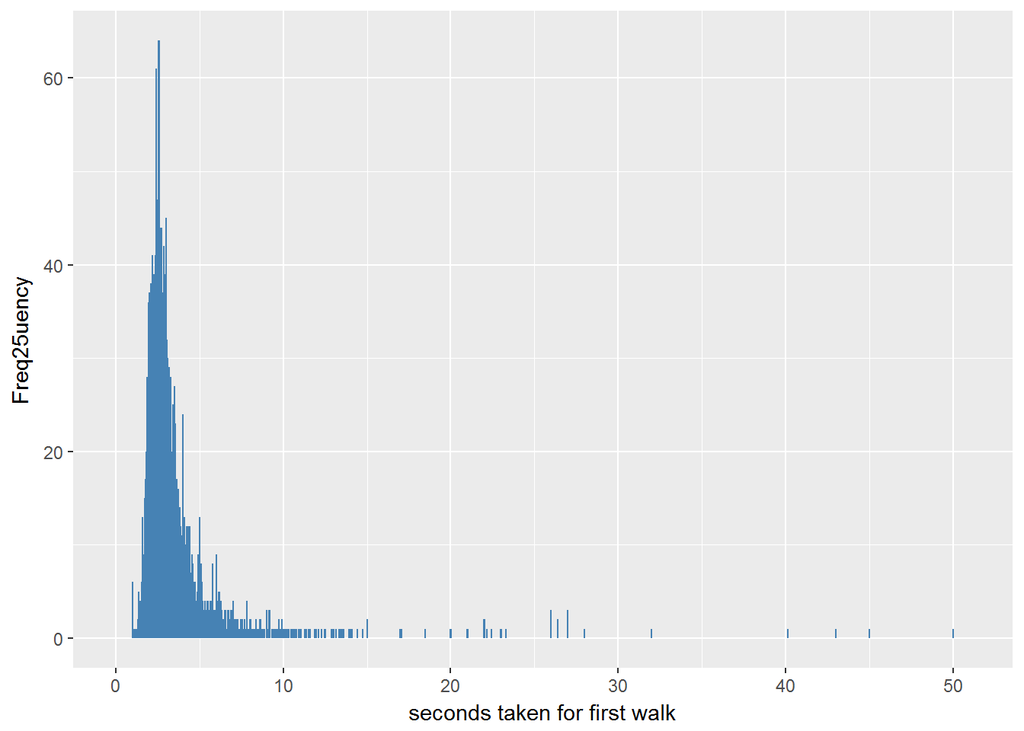

MMWlkB

| Sample size | Missing values |
| --- | --- |
| 9666 | 3553 |

Values

|  | No-missings | -8 | -1 | NA |
| --- | --- | --- | --- | --- |
| Frequency | 6113.00 | 1.00 | 3552.00 | 0 |
| Percentage | 63.24 | 0.01 | 36.75 | 0 |

Summary

| Min. | 1st Qu. | Median | Mean | 3rd Qu. | Max. |
| --- | --- | --- | --- | --- | --- |
| 1 | 2.26 | 2.72 | 3.182 | 3.44 | 50 |

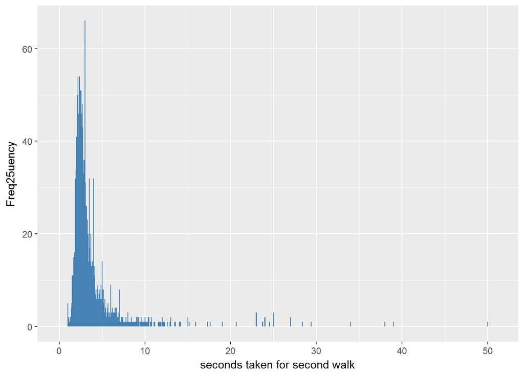

#### 2.1.7.2 Harmonisation algorithm

To compute the harmonize variable `walking_speed_c` from the study-specific variables it has to be computed the mean and recoded as follows:

- `-8 Don't Know into 998`
- `-1 Not applicable into 996`
- `NA into 999`

To compute the harmonized variable `walking_speed` from `walking_speed_c` it has to be recoded as follows:

- `walking_speed_c <=25% into 0`
- `walking_speed_c >25% into 1`

**R script:**

```r
ELSA_ds_w7 <- tibble(id = ELSA_w7_walking$id)
n <- length(ELSA_w7_walking$id)
mmwlk <- rep(0, length(ELSA_w7_walking$MMWlkA))
for (i in 1:n) {
    if (ELSA_w7_walking$MMWlkA[i] < 0 & ELSA_w7_walking$MMWlkB[i] >= 0)
        mmwlk[i] <- 2.44/ELSA_w7_walking$MMWlkB[i]

    if (ELSA_w7_walking$MMWlkB[i] < 0 & ELSA_w7_walking$MMWlkA[i] >= 0)
        mmwlk[i] <- 2.44/ELSA_w7_walking$MMWlkA[i]

    if (ELSA_w7_walking$MMWlkA[i] < 0 & ELSA_w7_walking$MMWlkB[i] < 0) {
        mmwlk[i] <- min(ELSA_w7_walking$MMWlkA[i], ELSA_w7_walking$MMWlkB[i])
    }

    if (ELSA_w7_walking$MMWlkA[i] >= 0 & ELSA_w7_walking$MMWlkB[i] >= 0)
        mmwlk[i] <- 2.44/mean(c(ELSA_w7_walking$MMWlkA[i], ELSA_w7_walking$MMWlkB[i]))
}
rm(i)


ELSA_ds_w7$walking_speed <- ELSA_ds_w7$walking_speed_c <- car::recode(as.numeric(unlist(mmwlk)),
    "-8 = '998';-1 = '996' ")

ELSA_ds_w7$walking_speed_c <- labelled(ELSA_ds_w7$walking_speed_c, labels = c(Missing = 999,
    `Do not know` = 998, Refuse = 997, `Not applicable` = 996, `Does not answer` = 995,
    `Not attempt not done` = 994, `Disable to measure` = 993, Impute = 992,
    `CAPI interviewer error` = 991))



## cut-off 25% is the R object 'q25' from wave 1.
q25 <- quantile(car::recode(ELSA_ds_w7$walking_speed_c, "999=NA; 997=NA; 998=NA; 996=NA"),
    probs = 1/4, na.rm = TRUE, names = FALSE)

ELSA_ds_w7$walking_speed[ELSA_ds_w7$walking_speed_c <= q25] <- 0
ELSA_ds_w7$walking_speed[ELSA_ds_w7$walking_speed_c > q25 & ELSA_ds_w7$walking_speed_c <
    990] <- 1

ELSA_ds_w7$walking_speed <- labelled(ELSA_ds_w7$walking_speed, labels = c(`<=25%` = 0,
    `>25%` = 1, Missing = 999, `Do not know` = 998, Refuse = 997, `Not applicable` = 996,
    `Does not answer` = 995, `Not attempt not done` = 994, `Disable to measure` = 993,
    Impute = 992, `CAPI interviewer error` = 991))
```

#### 2.1.7.3 Statistical description of the new harmonised variable

Walking speed

| Sample size | Missing values |
| --- | --- |
| 9666 | 3549 |

Values

|  | No-missings | 991 | 992 | 993 | 994 | 995 | 996 | 997 | 998 | 999 | NA |
| --- | --- | --- | --- | --- | --- | --- | --- | --- | --- | --- | --- |
| Frequency | 6117.00 | 0 | 0 | 0 | 0 | 0 | 3547.0 | 0 | 2.00 | 0 | 0 |
| Percentage | 63.28 | 0 | 0 | 0 | 0 | 0 | 36.7 | 0 | 0.02 | 0 | 0 |

Summary

| Min. | 1st Qu. | Median | Mean | 3rd Qu. | Max. |
| --- | --- | --- | --- | --- | --- |
| 0.0488 | 0.7022 | 0.8841 | 0.8773 | 1.054 | 2.44 |

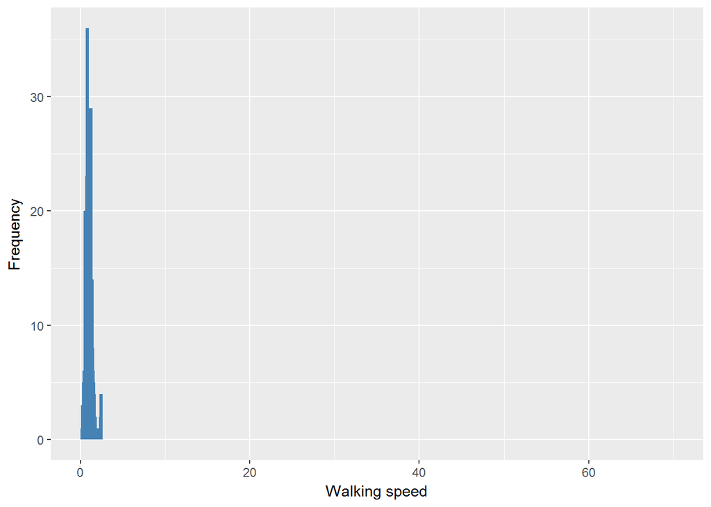

Walking speed

| Sample size | Missing values |
| --- | --- |
| 9666 | 3549 |

Category

|  | 0 | 1 |
| --- | --- | --- |
| Frequency | 1533.00 | 4584.00 |
| Percentage | 15.86 | 47.42 |

Type of missing

|  | 991 | 992 | 993 | 994 | 995 | 996 | 997 | 998 | 999 | NA |
| --- | --- | --- | --- | --- | --- | --- | --- | --- | --- | --- |
| Frequency | 0 | 0 | 0 | 0 | 0 | 3547.0 | 0 | 2.00 | 0 | 0 |
| Percentage | 0 | 0 | 0 | 0 | 0 | 36.7 | 0 | 0.02 | 0 | 0 |

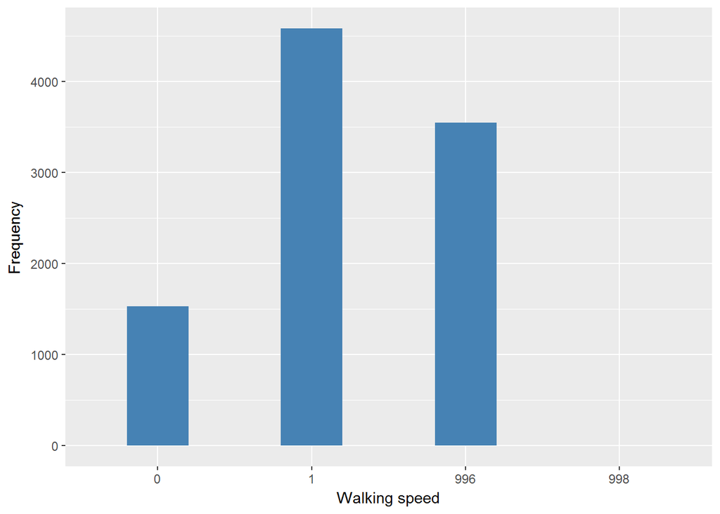

#### 2.1.7.4 Validation

Continuous vs Dichotomous

|  | 0:q25->0 | q25:900->1 | -1->996 | -8->998 |
| --- | --- | --- | --- | --- |
| Continous | 1533 | 4584 | 3547 | 2 |
| Dicotomic | 1533 | 4584 | 3547 | 2 |

## 2.2 Summary of descriptive statistics of the harmonised variable accross populations and waves

Two tables are generated:

1. Percentages of categories in each harmonised variable.
2. Freq25uencies and percentages of individuals with different trajectories. To avoid too large table, Only trajectories with percentages larger than 0.3 are shown.

**R script:**

```r
ELSA_ds_w1$walking_speed <- labelled(ELSA_ds_w1$walking_speed, labels = c(Presence = 0,
    Absence = 1, Missing = 999, Do_not_know = 998, Refuse = 997, Not_applicable = 996,
    Does_not_answer = 995, Not_attempt_not_done = 994, Disable_to_measure = 993,
    Impute = 992, CAPI_interviewer_error = 991))
ELSA_ds_w2$walking_speed <- labelled(ELSA_ds_w2$walking_speed, labels = c(Presence = 0,
    Absence = 1, Missing = 999, Do_not_know = 998, Refuse = 997, Not_applicable = 996,
    Does_not_answer = 995, Not_attempt_not_done = 994, Disable_to_measure = 993,
    Impute = 992, CAPI_interviewer_error = 991))
ELSA_ds_w3$walking_speed <- labelled(ELSA_ds_w3$walking_speed, labels = c(Presence = 0,
    Absence = 1, Missing = 999, Do_not_know = 998, Refuse = 997, Not_applicable = 996,
    Does_not_answer = 995, Not_attempt_not_done = 994, Disable_to_measure = 993,
    Impute = 992, CAPI_interviewer_error = 991))
ELSA_ds_w4$walking_speed <- labelled(ELSA_ds_w4$walking_speed, labels = c(Presence = 0,
    Absence = 1, Missing = 999, Do_not_know = 998, Refuse = 997, Not_applicable = 996,
    Does_not_answer = 995, Not_attempt_not_done = 994, Disable_to_measure = 993,
    Impute = 992, CAPI_interviewer_error = 991))
ELSA_ds_w5$walking_speed <- labelled(ELSA_ds_w5$walking_speed, labels = c(Presence = 0,
    Absence = 1, Missing = 999, Do_not_know = 998, Refuse = 997, Not_applicable = 996,
    Does_not_answer = 995, Not_attempt_not_done = 994, Disable_to_measure = 993,
    Impute = 992, CAPI_interviewer_error = 991))
ELSA_ds_w6$walking_speed <- labelled(ELSA_ds_w6$walking_speed, labels = c(Presence = 0,
    Absence = 1, Missing = 999, Do_not_know = 998, Refuse = 997, Not_applicable = 996,
    Does_not_answer = 995, Not_attempt_not_done = 994, Disable_to_measure = 993,
    Impute = 992, CAPI_interviewer_error = 991))
ELSA_ds_w7$walking_speed <- labelled(ELSA_ds_w7$walking_speed, labels = c(Presence = 0,
    Absence = 1, Missing = 999, Do_not_know = 998, Refuse = 997, Not_applicable = 996,
    Does_not_answer = 995, Not_attempt_not_done = 994, Disable_to_measure = 993,
    Impute = 992, CAPI_interviewer_error = 991))

tt <- frq(ELSA_ds_w1$walking_speed)[[1]][, c(1:2, 4)]
tt[4] <- frq(ELSA_ds_w2$walking_speed)[[1]][, c(4)]
tt[5] <- frq(ELSA_ds_w3$walking_speed)[[1]][, c(4)]
tt[6] <- frq(ELSA_ds_w4$walking_speed)[[1]][, c(4)]
tt[7] <- frq(ELSA_ds_w5$walking_speed)[[1]][, c(4)]
tt[8] <- frq(ELSA_ds_w6$walking_speed)[[1]][, c(4)]
tt[9] <- frq(ELSA_ds_w7$walking_speed)[[1]][, c(4)]
tt[13, ] <- c("n", "sample size", length(ELSA_ds_w1$walking_speed), length(ELSA_ds_w2$walking_speed),
    length(ELSA_ds_w3$walking_speed), length(ELSA_ds_w4$walking_speed), length(ELSA_ds_w5$walking_speed),
    length(ELSA_ds_w6$walking_speed), length(ELSA_ds_w7$walking_speed))
names(tt) <- c("val", "label", "w1", "w2", "w3", "w4", "w5", "w6", "w7")
kable(tt)
```

| val | label | w1 | w2 | w3 | w4 | w5 | w6 | w7 |
| --- | --- | --- | --- | --- | --- | --- | --- | --- |
| 0 | Presence | 12.85 | 14.72 | 13.43 | 11.93 | 15.63 | 15.22 | 15.86 |
| 1 | Absence | 38.44 | 43.96 | 40.28 | 45.01 | 46.89 | 45.66 | 47.42 |
| 991 | CAPI_interviewer_error | 0 | 0 | 0 | 0.01 | 0 | 0 | 0 |
| 992 | Impute | 0 | 0 | 0 | 0 | 0 | 0 | 0 |
| 993 | Disable_to_measure | 0 | 0 | 0 | 0 | 0 | 0 | 0 |
| 994 | Not_attempt_not_done | 0 | 0 | 0 | 0 | 0 | 0 | 0 |
| 995 | Does_not_answer | 0 | 0 | 0 | 0 | 0 | 0 | 0 |
| 996 | Not_applicable | 48.67 | 41.28 | 46.28 | 43 | 37.47 | 39.11 | 36.7 |
| 997 | Refuse | 0.03 | 0.01 | 0 | 0.01 | 0 | 0 | 0 |
| 998 | Do_not_know | 0 | 0.03 | 0.01 | 0.05 | 0.01 | 0.01 | 0.02 |
| 999 | Missing | 0 | 0 | 0 | 0 | 0 | 0 | 0 |
| NA | NA | 0 | 0 | 0 | 0 | 0 | 0 | 0 |
| n | sample size | 12099 | 9432 | 9771 | 11050 | 10274 | 10601 | 9666 |

```r
dbb <- merge(ELSA_m_ds_w1[, c("id", "walking_speed")], ELSA_m_ds_w2[, c("id",
    "walking_speed")], by = "id", suffixes = c(".w1", ".w2"), all = T)
dbb <- merge(dbb, ELSA_m_ds_w3[, c("id", "walking_speed")], by = "id", all = T)
dbb <- merge(dbb, ELSA_m_ds_w4[, c("id", "walking_speed")], by = "id", suffixes = c(".w3",
    ".w4"), all = T)
dbb <- merge(dbb, ELSA_m_ds_w5[, c("id", "walking_speed")], by = "id", all = T)
dbb <- merge(dbb, ELSA_m_ds_w6[, c("id", "walking_speed")], by = "id", suffixes = c(".w5",
    ".w6"), all = T)
dbb <- merge(dbb, ELSA_m_ds_w7[, c("id", "walking_speed")], by = "id", all = T)
names(dbb) <- c("id", "w1", "w2", "w3", "w4", "w5", "w6", "w7")
v.dbb <- paste(dbb[, 2], dbb[, 3], dbb[, 4], dbb[, 5], dbb[, 6], dbb[, 7], dbb[,
    8], sep = "")
f.dbb <- frq(v.dbb)[[1]][, c(1, 2, 4)]
kable(f.dbb[f.dbb[, 3] >= 0.3, ])
```

|  | val | frq | raw.prc |
| --- | --- | --- | --- |
| 11 | 0000NANANA | 69 | 0.37 |
| 29 | 000NANANANA | 125 | 0.68 |
| 70 | 00NANANANANA | 191 | 1.03 |
| 178 | 0NANANANANANA | 555 | 3.00 |
| 218 | 100NANANANA | 63 | 0.34 |
| 269 | 10NANANANANA | 133 | 0.72 |
| 312 | 110NANANANA | 60 | 0.32 |
| 332 | 1111000 | 59 | 0.32 |
| 340 | 1111100 | 76 | 0.41 |
| 341 | 1111101 | 57 | 0.31 |
| 343 | 1111110 | 118 | 0.64 |
| 344 | 1111111 | 656 | 3.55 |
| 345 | 111111NA | 130 | 0.70 |
| 348 | 11111NANA | 95 | 0.51 |
| 357 | 1111NANANA | 157 | 0.85 |
| 379 | 111NANANANA | 267 | 1.44 |
| 430 | 11NANANANANA | 404 | 2.19 |
| 535 | 1NANANANANANA | 727 | 3.93 |
| 582 | NA0NANANANANA | 88 | 0.48 |
| 635 | NA111111 | 266 | 1.44 |
| 661 | NA11NANANANA | 58 | 0.31 |
| 685 | NA1NANANANANA | 112 | 0.61 |
| 741 | NANA11111 | 225 | 1.22 |
| 772 | NANA1NANANANA | 94 | 0.51 |
| 797 | NANANA0NANANA | 67 | 0.36 |
| 810 | NANANA1110 | 80 | 0.43 |
| 811 | NANANA1111 | 820 | 4.44 |
| 812 | NANANA111NA | 135 | 0.73 |
| 815 | NANANA11NANA | 105 | 0.57 |
| 824 | NANANA1NANANA | 198 | 1.07 |
| 837 | NANANANA111 | 497 | 2.69 |
| 838 | NANANANA11NA | 91 | 0.49 |
| 841 | NANANANA1NANA | 99 | 0.54 |
| 846 | NANANANANA11 | 528 | 2.86 |
| 847 | NANANANANA1NA | 130 | 0.70 |
| 848 | NANANANANANA0 | 106 | 0.57 |
| 849 | NANANANANANA1 | 587 | 3.17 |
| 850 | NANANANANANANA | 5991 | 32.40 |

# 3 Quality estimation

The measure is created averaging the times obtained in the one/two trial/s available.